### Question 1

Что будет, если использовать в нейронных сетях линейную функцию активации?

Нейронная сеть будет строить линейную разделяющую поверхность, и при этом будет сильно переобучаться  
Нейронная сеть будет строить квадратичную разделяющую поверхность  
Такую нейронную сеть нельзя будет настраивать обратным распространением ошибки  
Нейронная сеть будет строить нелинейную разделяющую поверхность  
Нейронная сеть будет строить линейную разделяющую поверхность

### Question 2

Выберите функции, которые можно реализовать с помощью однослойной нейронной сети. Считайте, что все переменные бинарные, а функция активации — пороговая [x > 0].

x & z (логическое И)  
x | z (логическое ИЛИ)  
x == z (индикатор равенства)  
x xor z (исключающее ИЛИ)  
not(x and z) (штрих Шеффера)

### Question 3

Какими из перечисленных ниже свойств обладают нейронные сети?

Могут дообучаться на новых данных  
Дают хорошо интерпретируемые модели  
Практически не зависят от выбора параметров оптимизационного алгоритма  
Не переобучаются при увеличении числа параметров  
Могут восстанавливать очень сложные разделяющие поверхности

### Question 4

Рассмотрим полносвязную двухслойную нейронную сеть (т.е. у нее один скрытый и один выходной слой):

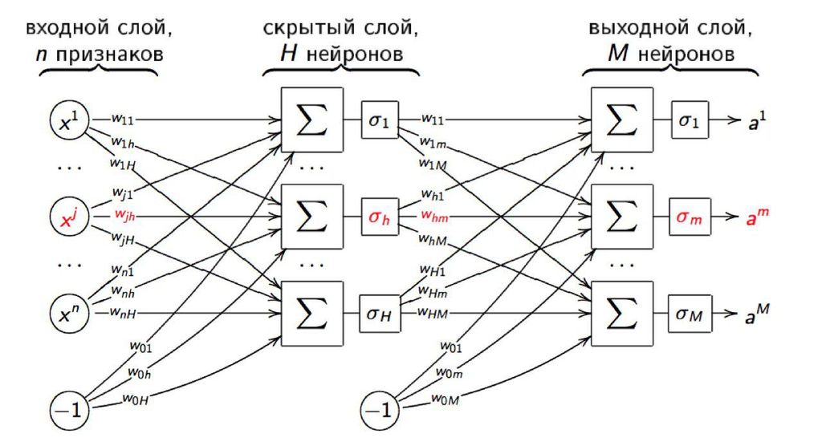

Пусть сеть принимает на вход три признака, содержит четыре нейрона во внутреннем слое и один нейрон в выходном слое. Сколько у нее параметров? Не забывайте про свободный член в каждом слое.